# CliMAF tour

### CliMAF is a framework for Climate Model Assessment. It allows to combine diagnostic binaries, scripts and Python functions as easily as possible It is documented on [ReadTheDocs](http://climaf.rtfd.org)

Init CliMAF  
Input data : projects, data location and datasets  
Defining and using operators based on external scripts and binaries  
File, cache and MA results  
Plotting  
Mixing CliMAF and Python  
Easy re-gridding  
Combining operators  
Derived variables  
Using CMIP5 data

# 1 - Init CliMAF, and resets its cache

```python
from climaf.api import *
craz()
```

```
Climaf version = 0.12
Cache directory set to : ~/tmp/climaf_cache (use $CLIMAF_CACHE if set)
Available macros read from ~/.climaf.macros are : []
```

### Depending on the depth of the demo , one may tell CliMAF to be more or less verbose (both on stderr and on logging file). Levels are : critical < error < warning (stderr default) < info (log file default) < debug

```python
#clog('info')
#clog_file('debug')
```

# 2 - Data location and datasets

### A 'project' means a data organization and a number of specific facets. It can have multiple data location roots. Let us declare project 'example' with only one additional facet. Note : All that is usually defined done in config files.

```python
cproject("example" , ("frequency","monthly") )
print cprojects['example'].facets
```

```
[__init__   : classes.py, L. 98  ] : WARNING  : Redefining project example
```

```
['project', 'simulation', 'variable', 'period', 'domain', 'frequency']
```

### For this project, we will use data in the distro.

```python
dataloc(project="example",organization="generic",url=[\
        cpath+"/../examples/data/${simulation}/L/${simulation}SFXYYYY.nc", \
        cpath+"/../examples/data/${simulation}/A/${simulation}PLYYYY.nc"])
```

```
<climaf.dataloc.dataloc instance at 0x7fc2f6738758>
```

### Define a default value for some dataset facets

```python
cdef("project","example")
cdef("period","1980-1981")
```

### Define a dataset based on a given simulation, and one variable (this uses the facets default values)

```python
tas_ds=ds(simulation="AMIPV6ALB2G", variable="tas")
```

### You can also define a dataset restricted to a latlon box

```python
tas_ds_r=ds(simulation="AMIPV6ALB2G", variable="tas", domain=[10,80,-50,40])
```

### Have a look at dataset's symbolic expression (other patterns could apply , according to project's "DRS")

```python
tas_ds_r
```

```
ds('example.AMIPV6ALB2G.tas.1980-1981.[10, 80, -50, 40].monthly')
```

### CliMAF can identify all the files relevant to the dataset (see CMIP5 DRS case further below, § 10)

```python
tas_ds.baseFiles()
```

```
'/cnrm/aster/data3/aster/vignonl/code/climaf/examples/data/AMIPV6ALB2G/L/AMIPV6ALB2GSFX1980.nc /cnrm/aster/data3/aster/vignonl/code/climaf/examples/data/AMIPV6ALB2G/L/AMIPV6ALB2GSFX1981.nc /cnrm/aster/data3/aster/vignonl/code/climaf/examples/data/AMIPV6ALB2G/L/AMIPV6ALB2GSFX1981.nc'
```

### It can also hande other organizations : CMIP5 DRS (see below), EM, CAMIobs and OBS4MIPs at CNRM, OCMIP5 on IPSL's Ciclad

To TOC

# 3 - Using external scripts and binaries for implementing diagnostics

### First diagnostic is basic climatology - Let us declare a 'CliMAF operator' for this diag, using an external binary and a few keywords conventions

```python
cscript('time_mean' ,'cdo timmean ${in} ${out}' )
```

```
CliMAF operator : time_mean
```

### Declaring a 'CliMAF operator' actually creates a Python function

```python
time_mean
```

```
<function climaf.operators.time_mean>
```

### A doc string is available for each 'operator function' as long a Rest syntax doc file exists with same name. Here, we just have the default doc.

```python
help(time_mean)
```

```
Help on function time_mean in module climaf.operators:

time_mean(*args, **dic)
    CliMAF wrapper for command : cdo timmean ${in} ${out}
```

### Symbolically apply the script to a dataset, using the 'CliMAF operator', and have a look at object result by displaying its expression in CliMAF Reference Syntax (CRS)

```python
tas_avg=time_mean(tas_ds)
tas_avg
```

```
time_mean(ds('example.AMIPV6ALB2G.tas.1980-1981.global.monthly'))
```

### Define another operator, apply it on result above, and look at CRS

```python
cscript('space_mean' ,'cdo fldavg ${in} ${out}' )
tas_ga=space_mean(tas_avg)
tas_ga
```

```
space_mean(time_mean(ds('example.AMIPV6ALB2G.tas.1980-1981.global.monthly')))
```

To TOC

# 4 - From CliMAF objects to files or Masked Array

### Computation actually occurs when wanting to 'export' objects in some way : here as a file using 'cfile'

```python
cfile(tas_avg)
```

```
Done in 0.4 s with script computation for select(ds('example.AMIPV6ALB2G.tas.1980-1981.global.monthly'))
Done in 0.1 s with script computation for time_mean(ds('example.AMIPV6ALB2G.tas.1980-1981.global.monthly'))
```

```
'/home/vignonl/tmp/climaf_cache/59/0.nc'
```

### The file cache will be used whenever the same object is requested (or even for an included objet). Here, in addition, we request a copy of the cache file, at some location

```python
cfile(tas_ds,"~/tmp/tasavg.nc")
```

```
'/home/vignonl/tmp/tasavg.nc'
```

### You can display the header information of a netCDF representation of a CliMAF object

```python
ncdump(tas_ds)
```

```
netcdf c {
dimensions:
	lon = 256 ;
	lat = 128 ;
	time = UNLIMITED ; // (36 currently)
variables:
	float lon(lon) ;
		lon:standard_name = "longitude" ;
		lon:long_name = "longitude" ;
		lon:units = "degrees_east" ;
		lon:axis = "X" ;
	float lat(lat) ;
		lat:standard_name = "latitude" ;
		lat:long_name = "latitude" ;
		lat:units = "degrees_north" ;
		lat:axis = "Y" ;
	double time(time) ;
		time:standard_name = "time" ;
		time:units = "days since 1975-01-01 00:00:00" ;
		time:calendar = "standard" ;
	float tas(time, lat, lon) ;
		tas:long_name = "2m_Temperature" ;
		tas:units = "K" ;
		tas:grid_type = "gaussian" ;
		tas:_FillValue = 1.e+20f ;
		tas:missing_value = 1.e+20f ;
		tas:comment = "instantaneous values" ;

// global attributes:
		:CDI = "Climate Data Interface version 1.6.9 (http://mpimet.mpg.de/cdi)" ;
		:Conventions = "CF-1.0" ;
		:history = "Mon Jan 04 17:10:33 2016: cdo copy climaf_mcdo_LsxkP8/AMIPV6ALB2GSFX1980.nc climaf_mcdo_LsxkP8/AMIPV6ALB2GSFX1981.nc climaf_mcdo_LsxkP8/AMIPV6ALB2GSFX1981.nc climaf_mcdo_LsxkP8/mcdo.sh.nc\n",
			"Mon Jan 04 17:10:33 2016: cdo -f nc seldate,1980-01-01T00:00:00,1981-12-31T23:59:00 -selname,tas /cnrm/aster/data3/aster/vignonl/code/climaf/examples/data/AMIPV6ALB2G/L/AMIPV6ALB2GSFX1980.nc climaf_mcdo_LsxkP8/AMIPV6ALB2GSFX1980.nc\n",
			"Mon Feb 16 16:03:44 2015: cdo selvar,tas,tasmin,tasmax,hfls,hfss AMIPV6ALB2GSFX1980.nc AMIPV6ALB2GSFX1980e.nc\n",
			"Thu Apr 10 07:47:44 2014: ncrcat -n 12,2,1 AMIPV6ALB2GSFX198001.nc AMIPV6ALB2GSFX1980.nc\n",
			"created at time: Thu Apr 10 07:47:07 2014" ;
		:institution = "CNRM (Centre National de Recherches Meteorologiques, Meteo-France, Toulouse, France)" ;
		:title = "[EXPE]" ;
		:nco_openmp_thread_number = 1 ;
		:CDO = "Climate Data Operators version 1.6.9 (http://mpimet.mpg.de/cdo)" ;
		:CRS_def = "select(ds(\'example.AMIPV6ALB2G.tas.1980-1981.global.monthly\'))" ;
		:CliMAF = "CLImate Model Assessment Framework version 0.12 (http://climaf.rtfd.org)" ;
}
```

```
ncdump(ds('example.AMIPV6ALB2G.tas.1980-1981.global.monthly'))
```

### Another export format : MaskedArrays (others could apply, as e.g. CDAT's MV)

```python
tas_avg_MA=cMA(tas_avg)
```

### Looking at the result

```python
type(tas_avg_MA)
```

```
numpy.ma.core.MaskedArray
```

```python
tas_avg_MA.shape
```

```
(1, 128, 256)
```

To TOC

# 5 - Basic and advanced displays

### Plot the data, first way : let us declare a 'CliMAF operator', for using binary 'ncview', which has no managed output

```python
cscript('my_ncview' ,'ncview ${in}')
```

```
CliMAF operator : my_ncview
```

### Using this operator is straightforward

```python
my_ncview(tas_avg)
```

```
my_ncview(time_mean(ds('example.AMIPV6ALB2G.tas.1980-1981.global.monthly')))
```

### 2nd plot : declare a simplified script plot with PNG output. Here in NCL with a number of args for graphics settings

```python
cscript('plotmap',\
        "ncl "+ cpath +"/../scripts/plotmap.ncl infile=${in} plotname=${out} \
                    cmap=${color} vmin=${min} vmax=${max} vdelta=${delta} var=${var} \
                    title=${title} scale=${scale} offset=${offset} units=${units}",format="png")
```

```
CliMAF operator : plotmap
```

### Applying the operator (actually, let us use a richer one: 'plot', a general purpose plot operator for plotting 1D and 2D datasets - maps, cross-sections and profiles -) The only effect is to define a figure object

```python
map=plot(tas_avg, min=260, max=300, delta=4)
map
```

```
plot(time_mean(ds('example.AMIPV6ALB2G.tas.1980-1981.global.monthly')),delta=4,max=300,min=260)
```

### Require the figure as a file; this leads to actually compute it if needed (i.e. launch the script)

```python
cfile(map)
```

```
Done in 1.0 s with script computation for plot(time_mean(ds('example.AMIPV6ALB2G.tas.1980-1981.global.monthly')),delta=4,max=300,min=260)
```

```
'/home/vignonl/tmp/climaf_cache/e8/8.png'
```

### 'cshow' will display the figure using the file cache [ Nothing will show on Web-only demo]

```python
cshow(map)
```

To TOC

# 6 - Mixing CliMAF basics and Python (and/or IPython)

### A more realistic way of configuring the NCL-based plots, using Python features for graphics settings on the basis of on plotted variable

### First define an auxiliary function

```python
def map_graph_attributes(var) :
    rep=dict()
    rep["offset"]=0.
    rep["scale"]=1.
    rep["color"]="BlueDarkRed18"
    if var=='tas' :
        rep["offset"]=-273.15 ;  rep["scale"]=1.0 ; rep["units"]="C"
        rep["min"]=-30  ; rep["max"]=30 ; rep["delta"]=2.
    return rep
```

### This allows to supply graphics attributes which are better tuned to the variable to display

```python
map2=plot(tas_avg,title="The Title",**map_graph_attributes(varOf(tas_avg)))
map2
```

```
plot(time_mean(ds('example.AMIPV6ALB2G.tas.1980-1981.global.monthly')),color='BlueDarkRed18',delta=2.0,max=30,min=-30,offset=-273.15,scale=1.0,title='The Title',units='C')
```

### Let launch the computation of the figure

```python
figfile=cfile(map2) ; print(figfile)
```

```
/home/vignonl/tmp/climaf_cache/ce/2.png
```

```
Done in 1.0 s with script computation for plot(time_mean(ds('example.AMIPV6ALB2G.tas.1980-1981.global.monthly')),color='BlueDarkRed18',delta=2.0,max=30,min=-30,offset=-273.15,scale=1.0,title='The Title',units='C')
```

### Bonus : using Ipython Notebook features for inline display

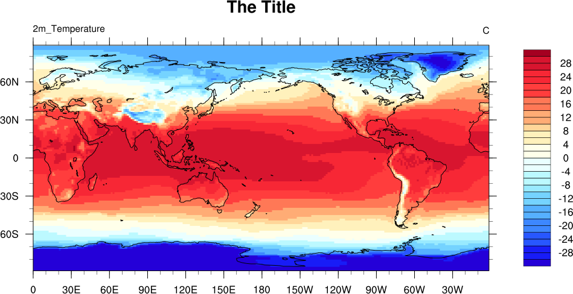

```python
from IPython.display import Image
Image(filename=figfile)
```

To TOC

# 7 - Remapping data

### For remapping a dataset to a named grid (known by cdo), let us use operator 'regridn'

```
Done in 0.1 s with script computation for regridn(time_mean(ds('example.AMIPV6ALB2G.tas.1980-1981.global.monthly')),cdogrid='r90x45')
Done in 0.9 s with script computation for plot(regridn(time_mean(ds('example.AMIPV6ALB2G.tas.1980-1981.global.monthly')),cdogrid='r90x45'),delta=4,max=300,min=260,title='2\xc2\xb0 Grid')
```

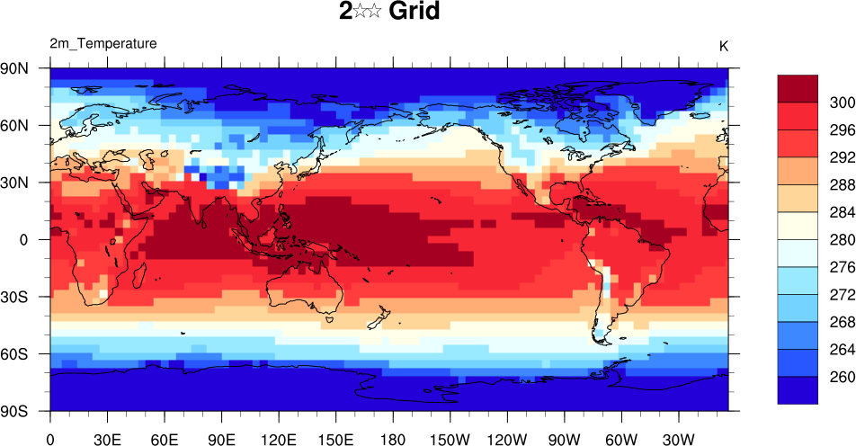

```python
dgr=regridn(tas_avg,cdogrid="r90x45")
mapgr=plot(dgr, title="2° Grid", min=260, max=300, delta=4)
Image(filename=cfile(mapgr))
```

### An other way is to regrid to the grid of another dataset, with 'regrid'; Let us use the dataset defined earlier on a latlon box

```python
dgr2=regrid(tas_ds, tas_ds_r)
ncview(dgr2)
```

```
Done in 0.3 s with script computation for select(ds('example.AMIPV6ALB2G.tas.1980-1981.[10, 80, -50, 40].monthly'))
Done in 0.1 s with script computation for regrid(ds('example.AMIPV6ALB2G.tas.1980-1981.global.monthly'),ds('example.AMIPV6ALB2G.tas.1980-1981.[10, 80, -50, 40].monthly'))
```

```
ncview(regrid(ds('example.AMIPV6ALB2G.tas.1980-1981.global.monthly'),ds('example.AMIPV6ALB2G.tas.1980-1981.[10, 80, -50, 40].monthly')))
```

To TOC

# 8 - Computing an annual cycle

### Let us compute an annual cycle, using swiss knife operator 'ccdo' (which applies cdo on a single dataset or object, with a cdo operator as argument), and look at it (nothing will show on Web only demo)

```python
anncycle=ccdo(tas_ds,operator='ymonavg')
ncview(anncycle)
```

```
Done in 0.4 s with script computation for ccdo(ds('example.AMIPV6ALB2G.tas.1980-1981.global.monthly'),operator='ymonavg')
```

```
ncview(ccdo(ds('example.AMIPV6ALB2G.tas.1980-1981.global.monthly'),operator='ymonavg'))
```

### Define the average annual cycle on a latlon box using operator 'llbox', plot it (January will show), and display the plot

```
Done in 0.1 s with script computation for llbox(ccdo(ds('example.AMIPV6ALB2G.tas.1980-1981.global.monthly'),operator='ymonavg'),latmax=60,latmin=30,lonmax=30,lonmin=-30)
Done in 0.9 s with script computation for plot(llbox(ccdo(ds('example.AMIPV6ALB2G.tas.1980-1981.global.monthly'),operator='ymonavg'),latmax=60,latmin=30,lonmax=30,lonmin=-30),delta=4,max=300,min=260,title='extract')
```

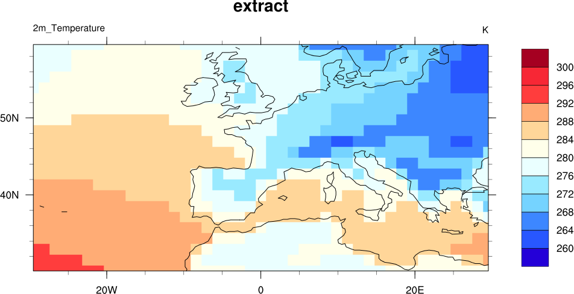

```python
extract=llbox(anncycle, latmin=30, latmax=60, lonmin=-30, lonmax=30)
map_extract=plot(extract, title='extract', min=260, max=300, delta=4)
Image(filename=cfile(map_extract))
```

### Let's compute the space average of annual cycle

```python
space_average=ccdo(extract,operator='fldavg')
```

### Creating a figure with standard operator 'curves'

```python
fig_avg=curves(space_average, title="Annual cycle")
```

### Get the figure computed, and get its filename in CliMAF file cache

```
Done in 0.1 s with script computation for ccdo(llbox(ccdo(ds('example.AMIPV6ALB2G.tas.1980-1981.global.monthly'),operator='ymonavg'),latmax=60,latmin=30,lonmax=30,lonmin=-30),operator='fldavg')
Done in 0.8 s with script computation for curves(ccdo(llbox(ccdo(ds('example.AMIPV6ALB2G.tas.1980-1981.global.monthly'),operator='ymonavg'),latmax=60,latmin=30,lonmax=30,lonmin=-30),operator='fldavg'),title='Annual cycle')
```

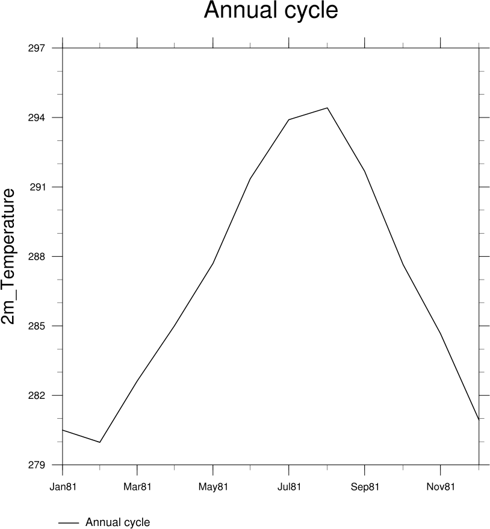

```python
Image(filename=cfile(fig_avg))
```

### Computation of seasonal average and plot bias

```python
# obs
if atCNRM : obs=ds(project='cruts3',variable='tas', period='1980-1981',grid='T127')
else :
    if onCiclad : obs=ds(project='ref_ipsl', variable='tas', period='1980-1981', product='ERAI')
    else :
        print("I do not know how to find data on this machine")
        exit(0)
anncycle_obs=ccdo(obs,operator='ymonavg')
```

```python
# seasonal average
JFM=ccdo(anncycle,operator='selmon,1,2,3')
JAS=ccdo(anncycle,operator='selmon,7,8,9')

JFM_obs=ccdo(anncycle_obs,operator='selmon,1,2,3')
JAS_obs=ccdo(anncycle_obs,operator='selmon,7,8,9')
```

```python
# bias
JFM_regrid=regrid(JFM,JFM_obs)
JFM_bias=minus(JFM_regrid,JFM_obs)

JAS_regrid=regrid(JAS,JAS_obs)
JAS_bias=minus(JAS_regrid,JAS_obs)
```

```
Done in 0.2 s with script computation for ccdo(ccdo(ds('example.AMIPV6ALB2G.tas.1980-1981.global.monthly'),operator='ymonavg'),operator='selmon,1,2,3')
Done in 1.0 s with script computation for plot(ccdo(ccdo(ds('example.AMIPV6ALB2G.tas.1980-1981.global.monthly'),operator='ymonavg'),operator='selmon,1,2,3'),contours=1,title='JFM')
Done in 0.2 s with script computation for ccdo(ccdo(ds('example.AMIPV6ALB2G.tas.1980-1981.global.monthly'),operator='ymonavg'),operator='selmon,7,8,9')
Done in 1.0 s with script computation for plot(ccdo(ccdo(ds('example.AMIPV6ALB2G.tas.1980-1981.global.monthly'),operator='ymonavg'),operator='selmon,7,8,9'),contours=1,title='JAS')
						[selectGene : dataloc.py, L. 334 ] : WARNING  : Cannot yet filter files re. time using only file content. TBD
Done in 1.9 s with script computation for ccdo(ds('cruts3.N/A.tas.1980-1981.global.T127'),operator='ymonavg')
Done in 0.2 s with script computation for ccdo(ccdo(ds('cruts3.N/A.tas.1980-1981.global.T127'),operator='ymonavg'),operator='selmon,1,2,3')
Done in 0.1 s with script computation for regrid(ccdo(ccdo(ds('example.AMIPV6ALB2G.tas.1980-1981.global.monthly'),operator='ymonavg'),operator='selmon,1,2,3'),ccdo(ccdo(ds('cruts3.N/A.tas.1980-1981.global.T127'),operator='ymonavg'),operator='selmon,1,2,3'))
Done in 0.1 s with script computation for minus(regrid(ccdo(ccdo(ds('example.AMIPV6ALB2G.tas.1980-1981.global.monthly'),operator='ymonavg'),operator='selmon,1,2,3'),ccdo(ccdo(ds('cruts3.N/A.tas.1980-1981.global.T127'),operator='ymonavg'),operator='selmon,1,2,3')),ccdo(ccdo(ds('cruts3.N/A.tas.1980-19…
Done in 1.0 s with script computation for plot(minus(regrid(ccdo(ccdo(ds('example.AMIPV6ALB2G.tas.1980-1981.global.monthly'),operator='ymonavg'),operator='selmon,1,2,3'),ccdo(ccdo(ds('cruts3.N/A.tas.1980-1981.global.T127'),operator='ymonavg'),operator='selmon,1,2,3')),ccdo(ccdo(ds('cruts3.N/A.tas.19…
Done in 0.2 s with script computation for ccdo(ccdo(ds('cruts3.N/A.tas.1980-1981.global.T127'),operator='ymonavg'),operator='selmon,7,8,9')
Done in 0.1 s with script computation for regrid(ccdo(ccdo(ds('example.AMIPV6ALB2G.tas.1980-1981.global.monthly'),operator='ymonavg'),operator='selmon,7,8,9'),ccdo(ccdo(ds('cruts3.N/A.tas.1980-1981.global.T127'),operator='ymonavg'),operator='selmon,7,8,9'))
Done in 0.1 s with script computation for minus(regrid(ccdo(ccdo(ds('example.AMIPV6ALB2G.tas.1980-1981.global.monthly'),operator='ymonavg'),operator='selmon,7,8,9'),ccdo(ccdo(ds('cruts3.N/A.tas.1980-1981.global.T127'),operator='ymonavg'),operator='selmon,7,8,9')),ccdo(ccdo(ds('cruts3.N/A.tas.1980-19…
Done in 1.0 s with script computation for plot(minus(regrid(ccdo(ccdo(ds('example.AMIPV6ALB2G.tas.1980-1981.global.monthly'),operator='ymonavg'),operator='selmon,7,8,9'),ccdo(ccdo(ds('cruts3.N/A.tas.1980-1981.global.T127'),operator='ymonavg'),operator='selmon,7,8,9')),ccdo(ccdo(ds('cruts3.N/A.tas.19…
```

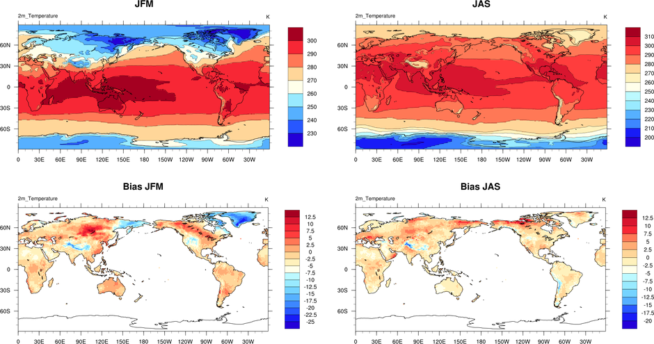

```python
# plot
JFM_map=plot(JFM,title='JFM',contours=1)
JAS_map=plot(JAS,title='JAS', contours=1)

#JFM_obs_map=plot(JFM_obs,title='JFM')
#JAS_obs_map=plot(JAS_obs,title='JAS')

JFM_bias_map=plot(JFM_bias,title='Bias JFM')
JAS_bias_map=plot(JAS_bias,title='Bias JAS')

multiplot=cpage([[JFM_map, JAS_map],[JFM_bias_map,JAS_bias_map]],heights=[0.2, 0.2])
Image(filename=cfile(multiplot))
```

To TOC

# 9 - Derived variables, the easy way

### Define a dataset using a variable name that is not in data files - i.e. a 'derived' variable

```python
creShortTop=ds(simulation="AMIPV6ALB2G",variable="crest")
```

### Declare a new 'CliMAF operator', to be used for computing the derived variable

```python
cscript('minus','cdo sub ${in_1} ${in_2} ${out}')
```

```
[__init__   : operators.py, L. 238 ] : WARNING  : Redefining CliMAF script minus
```

```
CliMAF operator : minus
```

### Tell how the derived variable is derived, for project 'example', using operator 'minus' and other variables

```python
derive('example','crest','minus','rst','rstcs')
```

### You can use the 'derived' dataset in any expression; computation will occur when needed

```python
my_ncview(creShortTop)
```

```
Done in 0.4 s with script computation for select(ds('example.AMIPV6ALB2G.rst.1980-1981.global.monthly'))
Done in 0.4 s with script computation for select(ds('example.AMIPV6ALB2G.rstcs.1980-1981.global.monthly'))
Done in 0.1 s with script computation for minus(ds('example.AMIPV6ALB2G.rst.1980-1981.global.monthly'),ds('example.AMIPV6ALB2G.rstcs.1980-1981.global.monthly'))
```

```
my_ncview(ds('example.AMIPV6ALB2G.crest.1980-1981.global.monthly'))
```

To TOC

# 10 - CliMAF access to data organized according to CMIP5 DRS

### This example will work as is on CNRM's Lustre and on IPSL's Ciclad, and can be easily tuned to other local CMIP5 datasets

### First, let us declare a list of data for CNRM-CM CMIP5 data at theses sites (note : this is actually built-in , and not necessary)

```python
urls_CMIP5_CNRM=["/cnrm/aster/data2/ESG/data1", "/cnrm/aster/data2/ESG/data2", "/cnrm/aster/data2/ESG/data5",
      "/cnrm/aster/data4/ESG/data6", "/cnrm/aster/data4/ESG/data7", "/cnrm/aster/data4/ESG/data8"]

urls_CMIP5_Ciclad=["/prodigfs/esg"]
```

### Declare locations for searching data for all projects, experiment and frequencies, and that data located in dirs listed in urls_CMIP5_CNRM and urls_CMIP5_Ciclad is organized as 'CMIP5_DRS'

```python
dataloc(project="CMIP5", organization="CMIP5_DRS", url=urls_CMIP5_CNRM+urls_CMIP5_Ciclad)
```

```
<climaf.dataloc.dataloc instance at 0x7fc2f670a710>
```

### Define a default value for some dataset facets

```python
cdef("frequency","monthly") ;  cdef("project","CMIP5")
```

### Define your dataset (a number of facets take default values)

```python
tas1pc=ds(model="CNRM-CM5", experiment="1pctCO2", variable="tas", period="1860-1861")
```

### Display the basic filenames involved in the dataset (all filenames in one single string). CliMAF will search them at the data location which is the most specific among all declared data locations

```python
files=tas1pc.baseFiles()
print files
```

```
/cnrm/aster/data2/ESG/data1/CMIP5/output1/CNRM-CERFACS/CNRM-CM5/1pctCO2/mon/atmos/Amon/r1i1p1/v20110701/tas/tas_Amon_CNRM-CM5_1pctCO2_r1i1p1_185001-189912.nc
```

### Let CliMAF generate a file with the exact dataset in its disk cache (select period and/or variables, aggregate files...)

```python
my_file=cfile(tas1pc)
print my_file
```

```
/home/vignonl/tmp/climaf_cache/9e/2.nc
```

```
Done in 0.4 s with script computation for select(ds('CMIP5.r1i1p1.tas.1860-1861.global.CNRM-CM5.1pctCO2.monthly.*.*.last'))
```

# Much more at http://climaf.readthedocs.org.

## You may use and/or contribute at various levels.